# Exercise correctness prediction

## Synopsis

The objective of this project is to use data from accelerometers on the belt, forearm, arm, and dumbell of 6 participants to predict how well they do the barbell lifts exercise. In the training set, 19622 observations with 160 variables are provided to build to model.

## Loading the data

```r
if (!file.exists("./pml-training.csv")) {
    download.file("http://d396qusza40orc.cloudfront.net/predmachlearn/pml-training.csv",
        destfile = "./pml-training.csv")
}
if (!file.exists("./pml-testing.csv")) {
    download.file("http://d396qusza40orc.cloudfront.net/predmachlearn/pml-testing.csv",
        destfile = "./pml-testing.csv")
}

train <- read.csv("./pml-training.csv")
test <- read.csv("./pml-testing.csv")
```

## Checking the data

```r
dim(train)
```

```
## [1] 19622   160
```

```r
dim(test)
```

```
## [1]  20 160
```

```r
str(train, list.len=160)
```

```
## 'data.frame':    19622 obs. of  160 variables:
##  $ X                       : int  1 2 3 4 5 6 7 8 9 10 ...
##  $ user_name               : Factor w/ 6 levels "adelmo","carlitos",..: 2 2 2 2 2 2 2 2 2 2 ...
##  $ raw_timestamp_part_1    : int  1323084231 1323084231 1323084231 1323084232 1323084232 1323084232 1323084232 1323084232 1323084232 1323084232 ...
##  $ raw_timestamp_part_2    : int  788290 808298 820366 120339 196328 304277 368296 440390 484323 484434 ...
##  $ cvtd_timestamp          : Factor w/ 20 levels "02/12/2011 13:32",..: 9 9 9 9 9 9 9 9 9 9 ...
##  $ new_window              : Factor w/ 2 levels "no","yes": 1 1 1 1 1 1 1 1 1 1 ...
##  $ num_window              : int  11 11 11 12 12 12 12 12 12 12 ...
##  $ roll_belt               : num  1.41 1.41 1.42 1.48 1.48 1.45 1.42 1.42 1.43 1.45 ...
##  $ pitch_belt              : num  8.07 8.07 8.07 8.05 8.07 8.06 8.09 8.13 8.16 8.17 ...
##  $ yaw_belt                : num  -94.4 -94.4 -94.4 -94.4 -94.4 -94.4 -94.4 -94.4 -94.4 -94.4 ...
##  $ total_accel_belt        : int  3 3 3 3 3 3 3 3 3 3 ...
##  $ kurtosis_roll_belt      : Factor w/ 397 levels "","-0.016850",..: 1 1 1 1 1 1 1 1 1 1 ...
##  $ kurtosis_picth_belt     : Factor w/ 317 levels "","-0.021887",..: 1 1 1 1 1 1 1 1 1 1 ...
##  $ kurtosis_yaw_belt       : Factor w/ 2 levels "","#DIV/0!": 1 1 1 1 1 1 1 1 1 1 ...
```

[output cut: 146 more lines]

## Cleaning the data

First, remove the variables that are irrelevent to the model such as X, user_name, and cvtd_timestamp (which displays the raw_timestamp in the date format).

Next, identify the variables that have near zero variance, those variables will contribute little to the model, so they are removed as well.

Last, remove the variables with mainly ‘NA’ values, those variables are also not useful to the model.

```r
remove <- grep("X|user_name|cvtd_timestamp", names(train))
train <- train[, -remove]
test <- test[, -remove]

remove <- nearZeroVar(train)
train <- train[, -remove]
test <- test[, -remove]

trim_train <- train[, colSums(is.na(train))==0]
trim_test <- test[, colSums(is.na(train))==0]

obs <- dim(trim_train)[1]
var <- dim(trim_train)[2]
```

The trimmed training set for the model has 19622 observations and 56 variables.

Next, split the trimmed training set into 2 sets; 70% for building the model, 30% for cross validation.

```r
set.seed(2014)
idx <- createDataPartition(y=trim_train$classe, p=0.7, list=FALSE)
train_test <- trim_train[idx,]
train_control <- trim_train[-idx,]

obs <- dim(train_test)[1]
obs2 <- dim(train_control)[1]
```

Now, we have 13737 observations for the building and 5885 observations for cross validation.

## Exploring the data

Then, check the correlation of the variables in the trimmed training set.

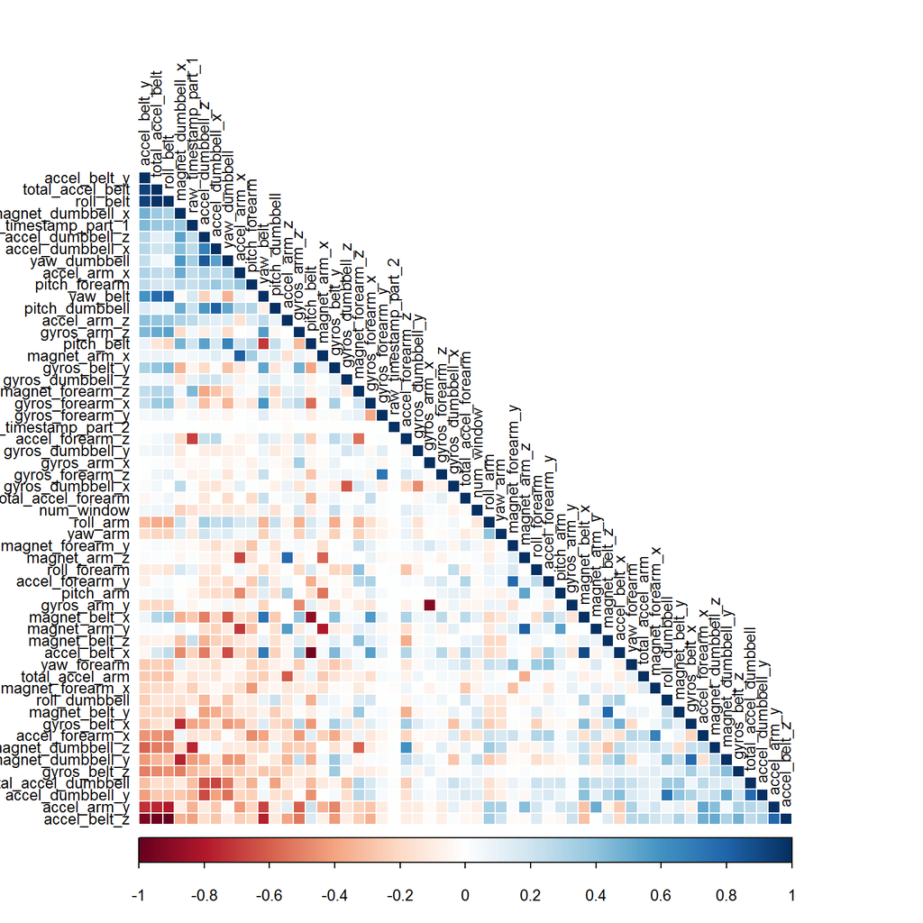

```r
corr <- cor(train_test[, -56])
corrplot(corr, order="FPC", type="lower", method="color", tl.cex=0.8, tl.col="black")
```

The above plot shows that there are some highly correlated variables (dark red for high negative correlation and dark blue for high positive correlation), and many slightly correlated ones. This observation suggests that using the Principal Components Analysis (PCA) will be an appropriate choice for preprocessing.

## Preprocessing the data

```r
preProc <- preProcess(train_test[, -56], method="pca")
train_test_pc <- predict(preProc, train_test[, -56])
train_control_pc <- predict(preProc, train_control[, -56])
preProc
```

```
##
## Call:
## preProcess.default(x = train_test[, -56], method = "pca")
##
## Created from 13737 samples and 55 variables
## Pre-processing: principal component signal extraction, scaled, centered
##
## PCA needed 28 components to capture 95 percent of the variance
```

## Building the model

PCA suggest that 28 predictors are needed to capture 95% of the variance. Given such dimensions, the random forest algorithm is used to build the model.

```r
ctrl <- trainControl(method="cv", number=4)
fit <- train(train_test$classe ~ ., method="rf", data=train_test_pc,
             trControl=ctrl, importance=TRUE)
fit
```

```
## Random Forest
##
## 13737 samples
##    27 predictor
##     5 classes: 'A', 'B', 'C', 'D', 'E'
##
## No pre-processing
## Resampling: Cross-Validated (4 fold)
##
## Summary of sample sizes: 10302, 10303, 10302, 10304
##
## Resampling results across tuning parameters:
##
##   mtry  Accuracy  Kappa  Accuracy SD  Kappa SD
##    2    0.968     0.960  0.00549      0.00695
##   15    0.960     0.949  0.00668      0.00845
##   28    0.948     0.934  0.00898      0.01136
##
## Accuracy was used to select the optimal model using  the largest value.
## The final value used for the model was mtry = 2.
```

## Cross validating the data

With the model, the next step is to check for out-of sample error using the 30% observations from the training set.

```r
rf_predict <- predict(fit, train_control_pc)
cm <- confusionMatrix(train_control$classe, rf_predict)
acc <- cm$overall[1]
ooserr <- 1-acc
cm
```

```
## Confusion Matrix and Statistics
##
##           Reference
## Prediction    A    B    C    D    E
##          A 1663    2    3    4    2
##          B   20 1103   15    1    0
##          C    3    5 1004   13    1
##          D    1    0   26  937    0
##          E    1    2   12    6 1061
##
## Overall Statistics
##
##                Accuracy : 0.9801
##                  95% CI : (0.9762, 0.9835)
##     No Information Rate : 0.2868
##     P-Value [Acc > NIR] : < 2.2e-16
##
##                   Kappa : 0.9748
##  Mcnemar's Test P-Value : 2.674e-06
##
## Statistics by Class:
##
##                      Class: A Class: B Class: C Class: D Class: E
## Sensitivity            0.9852   0.9919   0.9472   0.9750   0.9972
## Specificity            0.9974   0.9925   0.9954   0.9945   0.9956
## Pos Pred Value         0.9934   0.9684   0.9786   0.9720   0.9806
## Neg Pred Value         0.9941   0.9981   0.9885   0.9951   0.9994
## Prevalence             0.2868   0.1890   0.1801   0.1633   0.1808
## Detection Rate         0.2826   0.1874   0.1706   0.1592   0.1803
## Detection Prevalence   0.2845   0.1935   0.1743   0.1638   0.1839
## Balanced Accuracy      0.9913   0.9922   0.9713   0.9848   0.9964
```

The confusion matrix above shows the correctness of the predictions. The overall accuracy of the model is 0.9801189; the out-of-sample error is 0.0198811.

## Making prediction with the model

```r
test_pc <- predict(preProc, trim_test[, -56])
ans <- predict(fit, test_pc)
ans
```

```
##  [1] B A B A A E D B A A B C B A E E A B B B
## Levels: A B C D E
```